# EDA on COVID-19

Bowie

11/06/2020

```r
here()
```

```
## [1] "/Users/bowielam/Desktop/GitHub/COVID-19"
```

### Import data

```r
df <- read.csv(here("raw_data", "case_demographics_sex.csv"), na.strings = c("", ".", "NA", " ", "None"))

df
```

| sex | totalpositive2 | date | case_percent | deaths | deaths_percent | ca_percent |
| --- | --- | --- | --- | --- | --- | --- |
| Female | 5015 | 2020-04-02 | NA | NA | NA | NA |
| Male | 5547 | 2020-04-02 | NA | NA | NA | NA |
| Unknown | 139 | 2020-04-02 | NA | NA | NA | NA |
| Female | 5674 | 2020-04-03 | NA | NA | NA | NA |
| Male | 6202 | 2020-04-03 | NA | NA | NA | NA |
| Unknown | 150 | 2020-04-03 | NA | NA | NA | NA |
| Female | 6349 | 2020-04-04 | NA | NA | NA | NA |
| Male | 6876 | 2020-04-04 | NA | NA | NA | NA |
| Unknown | 213 | 2020-04-04 | NA | NA | NA | NA |
| Female | 6740 | 2020-04-05 | NA | NA | NA | NA |

[output cut: 645 more lines]

### Explore data attributes

```r
# investigate why NA is not populating in df
# df %>% filter(deaths == 'NA')
# df %>% filter(deaths == NA)
```

```r
# structure of dataset
str(df)
```

```
## 'data.frame':    655 obs. of  7 variables:
##  $ sex           : Factor w/ 4 levels "Female","Male",..: 1 2 4 1 2 4 1 2 4 1 ...
##  $ totalpositive2: int  5015 5547 139 5674 6202 150 6349 6876 213 6740 ...
##  $ date          : Factor w/ 217 levels "2020-04-02","2020-04-03",..: 1 1 1 2 2 2 3 3 3 4 ...
##  $ case_percent  : num  NA NA NA NA NA NA NA NA NA NA ...
##  $ deaths        : num  NA NA NA NA NA NA NA NA NA NA ...
##  $ deaths_percent: num  NA NA NA NA NA NA NA NA NA NA ...
##  $ ca_percent    : num  NA NA NA NA NA NA NA NA NA NA ...
```

```r
# view the different factors of `sex`
df$sex %>% unique()
```

```
## [1] Female      Male        Unknown     Transgender
## Levels: Female Male Transgender Unknown
```

```r
# view count of each unique `sex`
df %>% group_by(sex) %>% count()
```

| sex | n |
| --- | --- |
| Female | 218 |
| Male | 218 |
| Transgender | 1 |
| Unknown | 218 |

### Basic manipulations to data

```r
# add 'month' column
df$month <-as.numeric(substr(df$date, 6, 7))

# add 'day' column
df$day <-as.numeric(substr(df$date, 9, 10))

df
```

| sex | totalpositive2 | date | case_percent | deaths | deaths_percent | ca_percent | month | day |
| --- | --- | --- | --- | --- | --- | --- | --- | --- |
| Female | 5015 | 2020-04-02 | NA | NA | NA | NA | 4 | 2 |
| Male | 5547 | 2020-04-02 | NA | NA | NA | NA | 4 | 2 |
| Unknown | 139 | 2020-04-02 | NA | NA | NA | NA | 4 | 2 |
| Female | 5674 | 2020-04-03 | NA | NA | NA | NA | 4 | 3 |
| Male | 6202 | 2020-04-03 | NA | NA | NA | NA | 4 | 3 |
| Unknown | 150 | 2020-04-03 | NA | NA | NA | NA | 4 | 3 |
| Female | 6349 | 2020-04-04 | NA | NA | NA | NA | 4 | 4 |
| Male | 6876 | 2020-04-04 | NA | NA | NA | NA | 4 | 4 |
| Unknown | 213 | 2020-04-04 | NA | NA | NA | NA | 4 | 4 |
| Female | 6740 | 2020-04-05 | NA | NA | NA | NA | 4 | 5 |

[output cut: 645 more lines]

```r
# remove following characteristics:
# 'Transgender' and 'Unknown' from 'sex' column;
# 'November' from 'month' column
df <- df %>% filter(sex != "Transgender", sex != "Unknown", month != 11)

# remove 'date' column
df$date <- NULL

# rename 'totalpositive2' column
colnames(df)[names(df) == "totalpositive2"] <- "total_positive"

# arrange by 'day', then arrange by month (note: important for when diff() is used later on)
df <- df %>% arrange(day) %>% arrange(month)

df
```

| sex | total_positive | case_percent | deaths | deaths_percent | ca_percent | month | day |
| --- | --- | --- | --- | --- | --- | --- | --- |
| Female | 5015 | NA | NA | NA | NA | 4 | 2 |
| Male | 5547 | NA | NA | NA | NA | 4 | 2 |
| Female | 5674 | NA | NA | NA | NA | 4 | 3 |
| Male | 6202 | NA | NA | NA | NA | 4 | 3 |
| Female | 6349 | NA | NA | NA | NA | 4 | 4 |
| Male | 6876 | NA | NA | NA | NA | 4 | 4 |
| Female | 6740 | NA | NA | NA | NA | 4 | 5 |
| Male | 7296 | NA | NA | NA | NA | 4 | 5 |
| Female | 7600 | NA | NA | NA | NA | 4 | 6 |
| Male | 7957 | NA | NA | NA | NA | 4 | 6 |

[output cut: 418 more lines]

### Explore a small chunk of the data to better understand it as a whole

```r
# show dataframe of 'month' 'April' only
april <- df %>% filter(month == 4)

april
```

| sex | total_positive | case_percent | deaths | deaths_percent | ca_percent | month | day |
| --- | --- | --- | --- | --- | --- | --- | --- |
| Female | 5015 | NA | NA | NA | NA | 4 | 2 |
| Male | 5547 | NA | NA | NA | NA | 4 | 2 |
| Female | 5674 | NA | NA | NA | NA | 4 | 3 |
| Male | 6202 | NA | NA | NA | NA | 4 | 3 |
| Female | 6349 | NA | NA | NA | NA | 4 | 4 |
| Male | 6876 | NA | NA | NA | NA | 4 | 4 |
| Female | 6740 | NA | NA | NA | NA | 4 | 5 |
| Male | 7296 | NA | NA | NA | NA | 4 | 5 |
| Female | 7600 | NA | NA | NA | NA | 4 | 6 |
| Male | 7957 | NA | NA | NA | NA | 4 | 6 |

[output cut: 50 more lines]

```r
# notice that there are duplicate rows in the 'april' dataframe e.g. where month = 4 and day = 10

# create a function to remove duplicate rows
remove_dup <- function(dataframe) {
  return(dataframe[!duplicated(dataframe), ])
}

# create a function to double check for duplicates
check_for_dups <- function(dataframe) {
  len = dataframe %>% group_by(day) %>% count() %>% pull(n) %>% unique() %>% length()
  if (len != 1) {
    print("Oh, no! There are duplicates in this dataset! :( ")
  } else {
    print("Yay! There are no duplicates in this dataset! :) ")
  }
}
```

```r
# test remove_dup() and check_for_dups()

female_4 <- april %>% filter(sex == "Female")
female_4_cleaned <- remove_dup(female_4)

check_for_dups(female_4)
```

```
## [1] "Oh, no! There are duplicates in this dataset! :( "
```

```r
check_for_dups(female_4_cleaned)
```

```
## [1] "Yay! There are no duplicates in this dataset! :) "
```

```r
# apply remove_dup() to the entire dataset and reassign it
df <- remove_dup(df)
df
```

|  | sex | total_positive | case_percent | deaths | deaths_percent | ca_percent | month | day |
| --- | --- | --- | --- | --- | --- | --- | --- | --- |
| 1 | Female | 5015 | NA | NA | NA | NA | 4 | 2 |
| 2 | Male | 5547 | NA | NA | NA | NA | 4 | 2 |
| 3 | Female | 5674 | NA | NA | NA | NA | 4 | 3 |
| 4 | Male | 6202 | NA | NA | NA | NA | 4 | 3 |
| 5 | Female | 6349 | NA | NA | NA | NA | 4 | 4 |
| 6 | Male | 6876 | NA | NA | NA | NA | 4 | 4 |
| 7 | Female | 6740 | NA | NA | NA | NA | 4 | 5 |
| 8 | Male | 7296 | NA | NA | NA | NA | 4 | 5 |
| 9 | Female | 7600 | NA | NA | NA | NA | 4 | 6 |
| 10 | Male | 7957 | NA | NA | NA | NA | 4 | 6 |

[output cut: 416 more lines]

### Plot current `df` dataframe for observations

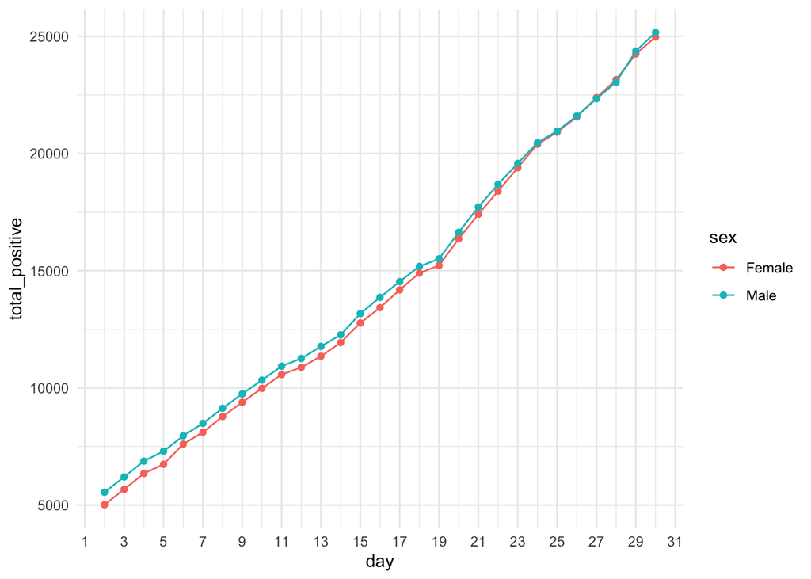

```r
# plot first available 'month' ('April') for both 'sex'
ggplot(data = df %>% filter(month == 4),
       aes(x = day, y = total_positive, color = sex, group = sex)) +
  geom_line() +
  geom_point() +
  scale_x_continuous(breaks = seq(min(df$day), max(df$day), 2)) +
  theme_minimal()
```

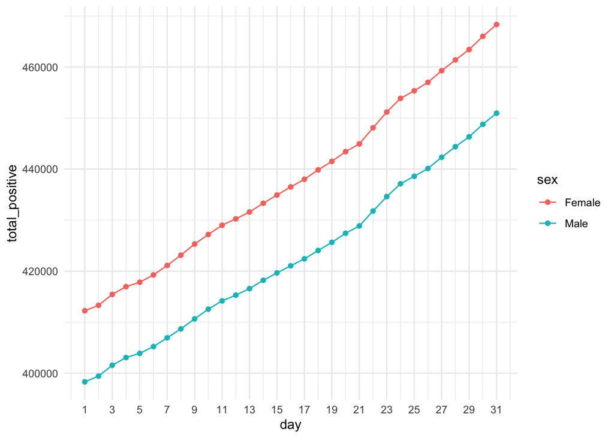

```r
# plot last available 'month' ('October') for both 'sex'
ggplot(data = df %>% filter(month == 10),
       aes(x = day, y = total_positive, color = sex, group = sex)) +
  geom_line() +
  geom_point() +
  scale_x_continuous(breaks = seq(min(df$day), max(df$day), 2)) +
  theme_minimal()
```

### Create new column that combines `month` and `day`

```r
# add a 'month.day' column
df$month.day <-
  as.numeric(str_replace_all(paste(as.character(df$month), ".", as.character(df$day)), fixed(" "), ""))

df
```

|  | sex | total_positive | case_percent | deaths | deaths_percent | ca_percent | month | day | month.day |
| --- | --- | --- | --- | --- | --- | --- | --- | --- | --- |
| 1 | Female | 5015 | NA | NA | NA | NA | 4 | 2 | 4.20 |
| 2 | Male | 5547 | NA | NA | NA | NA | 4 | 2 | 4.20 |
| 3 | Female | 5674 | NA | NA | NA | NA | 4 | 3 | 4.30 |
| 4 | Male | 6202 | NA | NA | NA | NA | 4 | 3 | 4.30 |
| 5 | Female | 6349 | NA | NA | NA | NA | 4 | 4 | 4.40 |
| 6 | Male | 6876 | NA | NA | NA | NA | 4 | 4 | 4.40 |
| 7 | Female | 6740 | NA | NA | NA | NA | 4 | 5 | 4.50 |
| 8 | Male | 7296 | NA | NA | NA | NA | 4 | 5 | 4.50 |
| 9 | Female | 7600 | NA | NA | NA | NA | 4 | 6 | 4.60 |
| 10 | Male | 7957 | NA | NA | NA | NA | 4 | 6 | 4.60 |

[output cut: 416 more lines]

### Given current state of `df` dataframe, analayze where `sex` is `Female`

```r
females_df <- df %>% filter(sex == "Female")
females_df
```

| sex | total_positive | case_percent | deaths | deaths_percent | ca_percent | month | day | month.day |
| --- | --- | --- | --- | --- | --- | --- | --- | --- |
| Female | 5015 | NA | NA | NA | NA | 4 | 2 | 4.20 |
| Female | 5674 | NA | NA | NA | NA | 4 | 3 | 4.30 |
| Female | 6349 | NA | NA | NA | NA | 4 | 4 | 4.40 |
| Female | 6740 | NA | NA | NA | NA | 4 | 5 | 4.50 |
| Female | 7600 | NA | NA | NA | NA | 4 | 6 | 4.60 |
| Female | 8108 | NA | NA | NA | NA | 4 | 7 | 4.70 |
| Female | 8776 | NA | NA | NA | NA | 4 | 8 | 4.80 |
| Female | 9387 | NA | NA | NA | NA | 4 | 9 | 4.90 |
| Female | 9981 | NA | NA | NA | NA | 4 | 10 | 4.10 |
| Female | 10571 | NA | NA | NA | NA | 4 | 11 | 4.11 |

[output cut: 203 more lines]

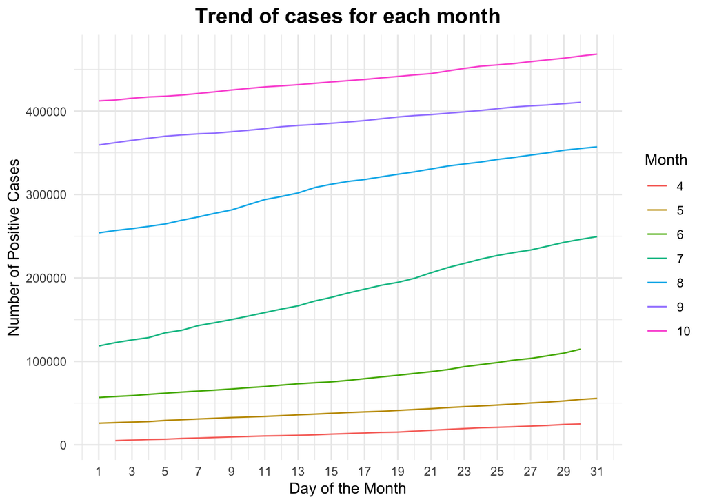

```r
# plot where each lines represents a 'month' for 'Female'
options(scipen = 5)
ggplot(data = females_df,
       aes(x = day, y = total_positive, color = as.factor(month), group = month)) +
  geom_line() +
  labs(title = "Trend of cases for each month", x = "Day of the Month", y = "Number of Positive Cases") +
  scale_x_continuous(breaks = seq(min(df$day), max(df$day), 2)) +
  theme_minimal() +
  theme(plot.title = element_text(size = 15, face = "bold", hjust = 0.5)) + # legend.position = "none"
  scale_colour_discrete("Month")
```

### Given current state of `df` dataframe, analayze where `sex` is `Male`

```r
males_df <- df %>% filter(sex == "Male")
males_df
```

| sex | total_positive | case_percent | deaths | deaths_percent | ca_percent | month | day | month.day |
| --- | --- | --- | --- | --- | --- | --- | --- | --- |
| Male | 5547 | NA | NA | NA | NA | 4 | 2 | 4.20 |
| Male | 6202 | NA | NA | NA | NA | 4 | 3 | 4.30 |
| Male | 6876 | NA | NA | NA | NA | 4 | 4 | 4.40 |
| Male | 7296 | NA | NA | NA | NA | 4 | 5 | 4.50 |
| Male | 7957 | NA | NA | NA | NA | 4 | 6 | 4.60 |
| Male | 8488 | NA | NA | NA | NA | 4 | 7 | 4.70 |
| Male | 9130 | NA | NA | NA | NA | 4 | 8 | 4.80 |
| Male | 9745 | NA | NA | NA | NA | 4 | 9 | 4.90 |
| Male | 10330 | NA | NA | NA | NA | 4 | 10 | 4.10 |
| Male | 10926 | NA | NA | NA | NA | 4 | 11 | 4.11 |

[output cut: 203 more lines]

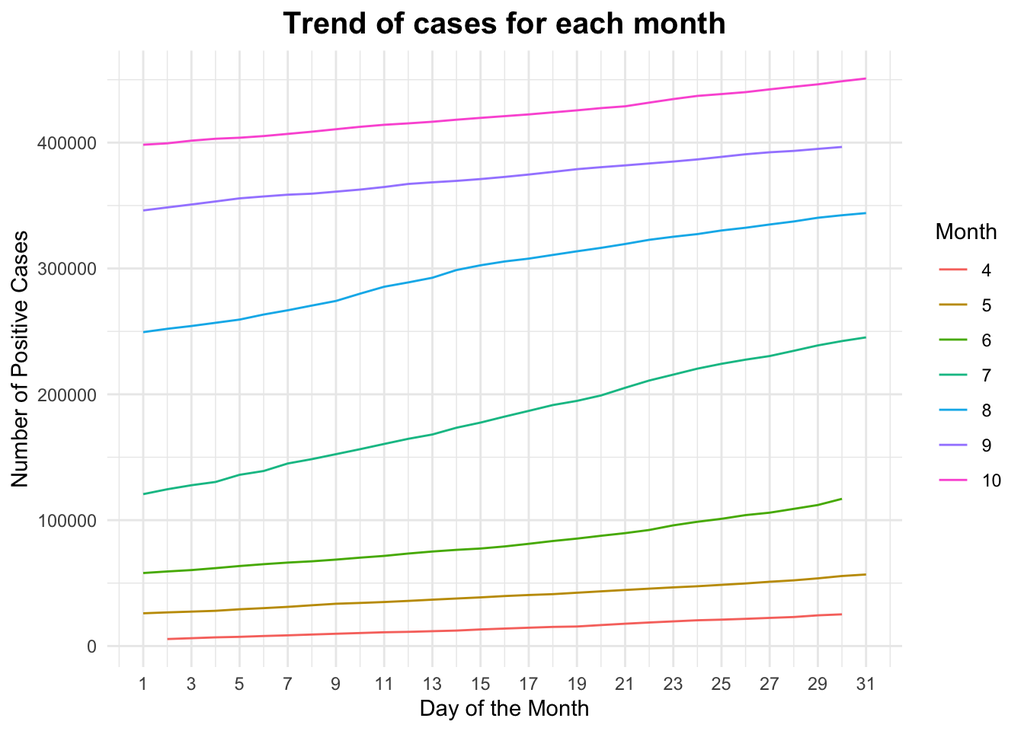

```r
# plot where each lines represents a 'month' for 'Male'
options(scipen = 5)
ggplot(data = males_df,
       aes(x = day, y = total_positive, color = as.factor(month), group = month)) +
  geom_line() +
  labs(title = "Trend of cases for each month", x = "Day of the Month", y = "Number of Positive Cases") +
  scale_x_continuous(breaks = seq(min(df$day), max(df$day), 2)) +
  theme_minimal() +
  theme(plot.title = element_text(size = 15, face = "bold", hjust = 0.5)) + # legend.position = "none"
  scale_colour_discrete("Month")
```

### Use `diff()` function for all `sex` to find fluctuation in for all days

##### I had to separate `df` into `females_df` and `males_df` because if I use `diff()` on `df` where the rows alternate between `Male` and `Female`, the `difference` column produced will be incorrect. Thus, in this section I separate the main dataframe by `sex`, compute `diff()` on each dataframe, then bind the two and reassign to the main dataframe, `df`.

```r
# add 'difference' column to `females_df` dataframe
females_df$difference <- c(0, diff(females_df$total_positive))

females_df
```

| sex | total_positive | case_percent | deaths | deaths_percent | ca_percent | month | day | month.day | difference |
| --- | --- | --- | --- | --- | --- | --- | --- | --- | --- |
| Female | 5015 | NA | NA | NA | NA | 4 | 2 | 4.20 | 0 |
| Female | 5674 | NA | NA | NA | NA | 4 | 3 | 4.30 | 659 |
| Female | 6349 | NA | NA | NA | NA | 4 | 4 | 4.40 | 675 |
| Female | 6740 | NA | NA | NA | NA | 4 | 5 | 4.50 | 391 |
| Female | 7600 | NA | NA | NA | NA | 4 | 6 | 4.60 | 860 |
| Female | 8108 | NA | NA | NA | NA | 4 | 7 | 4.70 | 508 |
| Female | 8776 | NA | NA | NA | NA | 4 | 8 | 4.80 | 668 |
| Female | 9387 | NA | NA | NA | NA | 4 | 9 | 4.90 | 611 |
| Female | 9981 | NA | NA | NA | NA | 4 | 10 | 4.10 | 594 |
| Female | 10571 | NA | NA | NA | NA | 4 | 11 | 4.11 | 590 |

[output cut: 203 more lines]

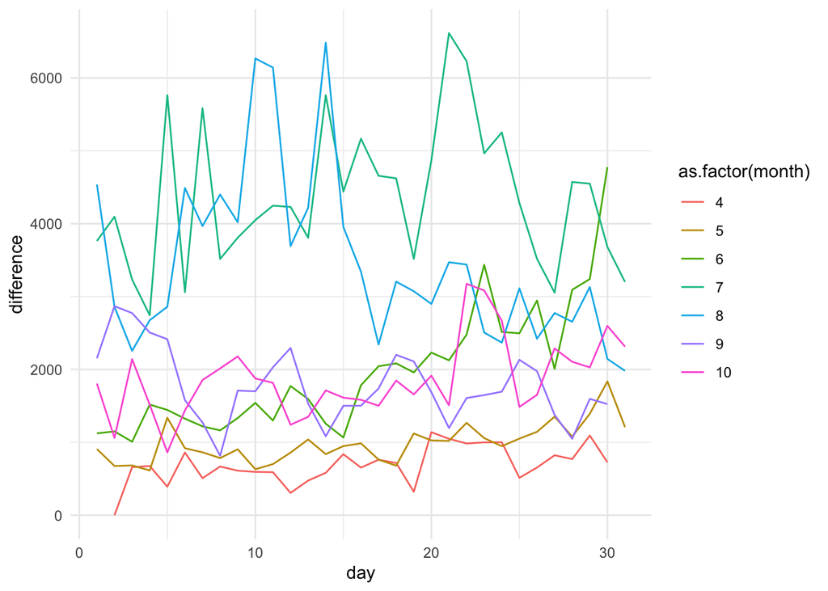

```r
# plot `difference` in cases between days for each month for `Female`
ggplot(data = females_df,
       aes(x = day, y = difference, color = as.factor(month), group = month)) +
  geom_line() +
  theme_minimal()
```

```r
# add 'difference' column to `males_df` dataframe
males_df$difference <- c(0, diff(males_df$total_positive))

males_df
```

| sex | total_positive | case_percent | deaths | deaths_percent | ca_percent | month | day | month.day | difference |
| --- | --- | --- | --- | --- | --- | --- | --- | --- | --- |
| Male | 5547 | NA | NA | NA | NA | 4 | 2 | 4.20 | 0 |
| Male | 6202 | NA | NA | NA | NA | 4 | 3 | 4.30 | 655 |
| Male | 6876 | NA | NA | NA | NA | 4 | 4 | 4.40 | 674 |
| Male | 7296 | NA | NA | NA | NA | 4 | 5 | 4.50 | 420 |
| Male | 7957 | NA | NA | NA | NA | 4 | 6 | 4.60 | 661 |
| Male | 8488 | NA | NA | NA | NA | 4 | 7 | 4.70 | 531 |
| Male | 9130 | NA | NA | NA | NA | 4 | 8 | 4.80 | 642 |
| Male | 9745 | NA | NA | NA | NA | 4 | 9 | 4.90 | 615 |
| Male | 10330 | NA | NA | NA | NA | 4 | 10 | 4.10 | 585 |
| Male | 10926 | NA | NA | NA | NA | 4 | 11 | 4.11 | 596 |

[output cut: 203 more lines]

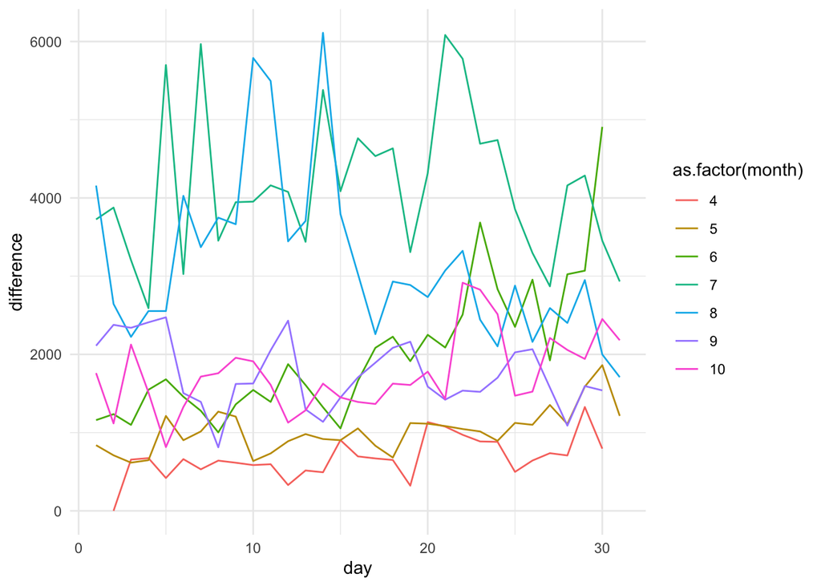

```r
# plot `difference` in cases between days for each month for `Female`
ggplot(data = males_df,
       aes(x = day, y = difference, color = as.factor(month), group = month)) +
  geom_line() +
  theme_minimal()
```

```r
# combine `females_df` and `males_df` and reassign to `df` dataframe
df <- rbind(females_df, males_df)

df
```

| sex | total_positive | case_percent | deaths | deaths_percent | ca_percent | month | day | month.day | difference |
| --- | --- | --- | --- | --- | --- | --- | --- | --- | --- |
| Female | 5015 | NA | NA | NA | NA | 4 | 2 | 4.20 | 0 |
| Female | 5674 | NA | NA | NA | NA | 4 | 3 | 4.30 | 659 |
| Female | 6349 | NA | NA | NA | NA | 4 | 4 | 4.40 | 675 |
| Female | 6740 | NA | NA | NA | NA | 4 | 5 | 4.50 | 391 |
| Female | 7600 | NA | NA | NA | NA | 4 | 6 | 4.60 | 860 |
| Female | 8108 | NA | NA | NA | NA | 4 | 7 | 4.70 | 508 |
| Female | 8776 | NA | NA | NA | NA | 4 | 8 | 4.80 | 668 |
| Female | 9387 | NA | NA | NA | NA | 4 | 9 | 4.90 | 611 |
| Female | 9981 | NA | NA | NA | NA | 4 | 10 | 4.10 | 594 |
| Female | 10571 | NA | NA | NA | NA | 4 | 11 | 4.11 | 590 |

[output cut: 416 more lines]

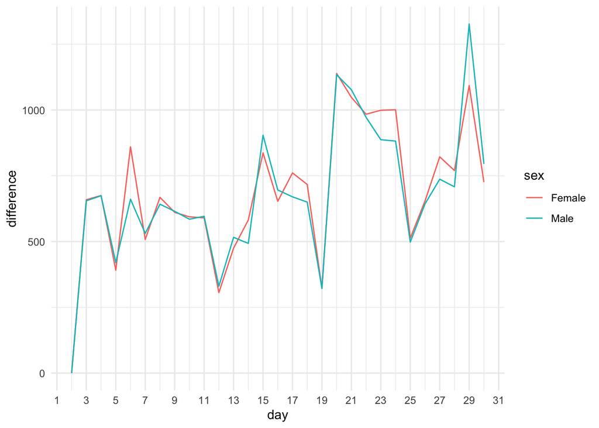

```r
# plot 'difference' for where 'month' is '4' (the first available month) between all 'sex'
ggplot(data = df %>% filter(month == 4),
       aes(x = day, y = difference, color = sex, group = sex)) +
  geom_line() +
  scale_x_continuous(breaks = seq(min(df$day), max(df$day), 2)) +
  theme_minimal()
```

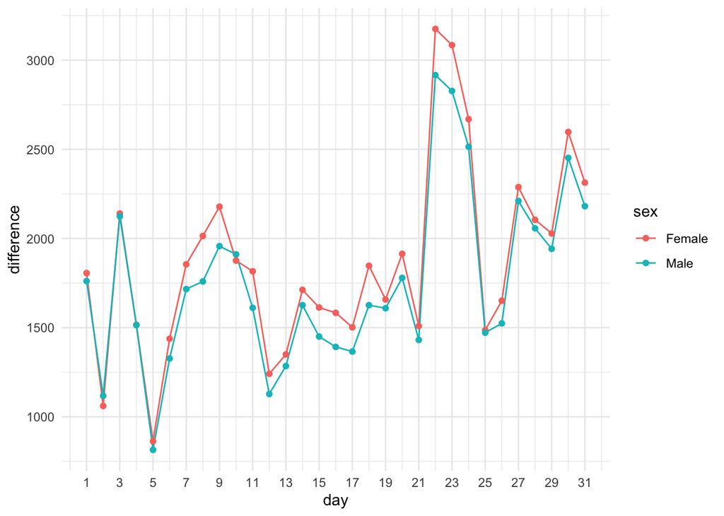

```r
# plot 'difference' for where 'month' is '10' (the last available month) between all 'sex'
ggplot(data = df %>% filter(month == 10),
       aes(x = day, y = difference, color = sex, group = sex)) +
  geom_line() +
  geom_point() +
  scale_x_continuous(breaks = seq(min(df$day), max(df$day), 2)) +
  theme_minimal()
```

```r
# min() of the 'difference' column
min(df$difference)
```

```
## [1] 0
```

```r
# max() of the 'difference' column
max(df$difference)
```

```
## [1] 6615
```

### Some things to think about at this point:

Shiny App

- Plot for where user can view…
  - the number of cases for a particular month between both sexes
  - the trend of number of cases for all months for a particular sex
  - the fluctuation (difference) of cases for a particular sex between 2+ months
  - the fluctuation (difference) of cases for a particular month between both sexes
- Questions?
  - How can I setup widgets, so that Widget A is the main widget and whatever choice the user makes results in specific available widgets?

Other

- Investigate why code is unable to populate empty cells with NA.